# Отчёт по лабораторной работе №5

Менеджер паролей pass и управление конфигурациями chezmoi

Автор

принадлежность

Семёнов Александр Дмитриевич, Student

Российский университет дружбы народов

Дата публикации

2026-03-14

# Информация

## Докладчик

- Семёнов Александр Дмитриевич
- Группа НКАбд-05-25, студент бакалавра
- Российский университет дружбы народов им. П. Лумумбы
- 103252587@rudn.ru
- https://github.com/rudn103225

# Вводная часть

## Цель работы

Освоить использование менеджера паролей pass для безопасного хранения учётных данных и систему управления кофигурацинными файлами chezmoi для синхронизации настроек рабочей среды.

## Задание

- Установить и настроить менеджер паролей pass
- Установить и настроить chezmoi

## Теоретическое введение

**Менеджер паролей pass**

pass (The standard Unix password manager) — менеджер паролей, следующий философии Unix. Основные принципы работы:

- Хранение данных: пароли сохраняются в файловой системе в виде обычных файлов, организованных в каталоги.
- Безопасность: каждый файл шифруется с помощью GPG-ключа пользователя.
- Структура базы: может быть произвольной, но для совместимости с дополнительным ПО рекомендуется семантическая структура (например, example.com/user.gpg, user@example.com.gpg).
- Синхронизация: поддерживается работа с Git, что позволяет хранить базу паролей в удалённом репозитории и использовать её на нескольких устройствах.

**Управление конфигурационными файлами с chezmoi**

chezmoi — инструмент для управления dotfiles (конфигурационными файлами) в домашнем каталоге пользователя.

Основные возможности:

- Хранение: состояние файлов сохраняется в ~/.local/share/chezmoi, который является клоном Git-репозитория.
- Шаблоны: поддержка шаблонов Go (синтаксис {{ .variable }}) для создания конфигураций, адаптируемых под разные машины.
- Переменные: доступ к данным окружения через chezmoi data (ОС, имя хоста, архитектура и др.).
- Условные выражения: возможность включать/исключать части конфигурации в зависимости от условий (if, eq, and, or).
- Работа с несколькими машинами: простая инициализация новой машины одной командой (chezmoi init –apply), автоматическая синхронизация изменений.

# Выполнение лабораторной работы

## Настройка

Посмотрел список ключей (рис. 3).

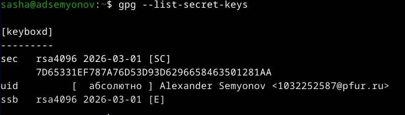

Рисунок 3: Список ключей

Инициализировала хранилище (рис. 4).

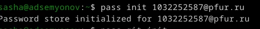

Рисунок 4: Инициализация хранилища

Создал структуру git и задал адрес репозитория на хостинге, предварительно создав репозиторий (рис. 5).

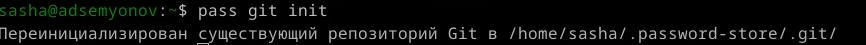

Рисунок 5: Создание структуры git

Выполнил следующую команду для синхронизации (рис. 6).

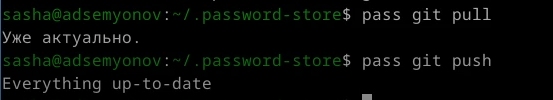

Рисунок 6: Синхронизация

## Настройка интерфейса с браузером

Я установил интерфейс для взаимодейтсвия с браузером (рис. 7).

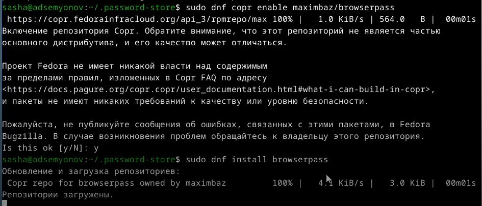

Рисунок 7: Установка интерфейса

## **Дополнительное программное обеспечение**

Я установил дополнительное программное обеспечение (рис. 8).

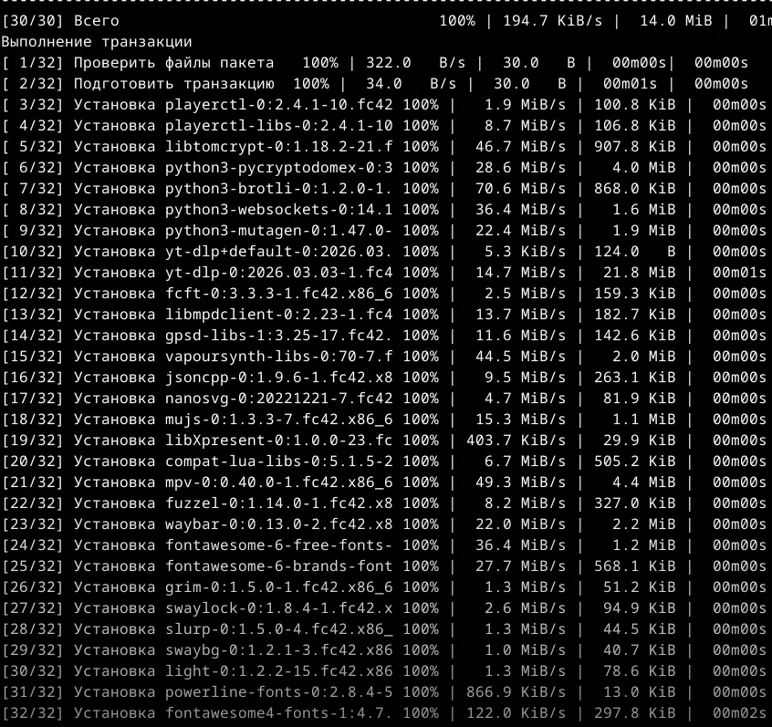

Рисунок 8: Дополнительное ПО

## Установка

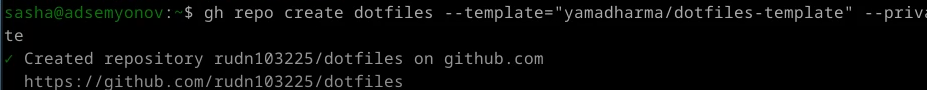

## Подключение репозитория к своей системе

Далее инициализировал chezmoi с моим репозиторием dotfiles (рис. 10).

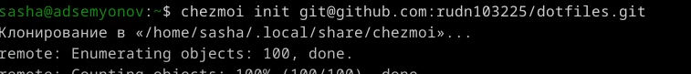

Рисунок 10: Инициализация chezmoi

## Ежедневные операции с chezmoi

Я извлекл изменения из репозитория и применила их. Потом извлекл изменения и посмотрел, что изменится, фактически не применяя изменения. И т.к. я доволен изменениями, я применил их (рис. 13).

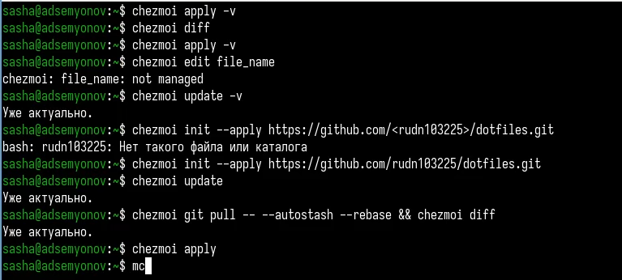

Рисунок 13: Просмотр и применение изменений

Чтобы автоматически фиксировать и отправлять изменения в репозиторий, я добавил в файл конфигурации ~/.config/chezmoi/chezmoi.toml следующее: (рис. 14).

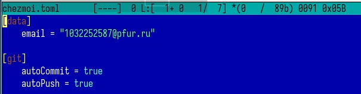

Рисунок 14: Файл конфигурации

# Выводы

Я освоил использование менеджера паролей зфыы для безопасного хранения учётных данных и систему управления кофигурацинными файлами chezmoi для синхронизации настроек рабочей среды.

# Список литературы

[ТУИС](https://esystem.rudn.ru/)